# Hippocampus reidi in Brazil

FISH 274

## **Introduction**

This presentation shows the size and locations for visible

*Hippocampus reidi* populations off the coast of Brazil. Its

purpose is to help snorkelers and scuba divers who want to

view seahorses in the wild. The data will compare the size

and population trends of the locations.

## **Locations in Brazil sampled for *Hippocampus reidi***

- Camurupim
- Ubatuba
- Pacoti
- Mal Cozinhado
- Tubarão
- Casqueira
- Mamanguape
- Itapessoca
- Ariquindá
- Andorinhas
- Itaipu
- Penha

The range of *Hippocampus reidi* is Cape Hatteras, United States to Brazil and the Gulf of Mexico

## **Map of Seahorse Sample Locations**

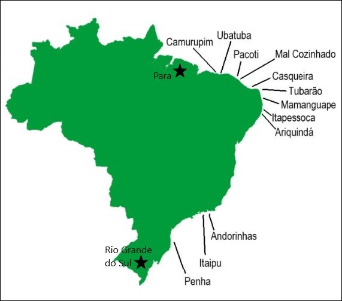

Image of Brazil

Within Brazil

they are

found from the

northern state of

Pará (Salgado

region) to the

southern state of

Rio Grande do

Sul.

## **How to Find Them**

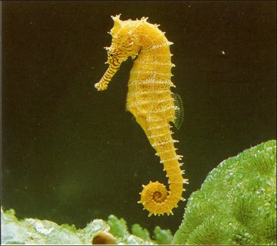

Image of *Hippocampus reidi*

*Hippocampus reidi* can

be found down to 55

centimeters long. They

are found in coral

reefs and seagrass

beds.

## *Hippocampus reidi* in Action

[figure not shown]

Video of *Hippocampus reidi*

Also known as the

longsnout seahorse

males and females are

easily distinguished

due to their bright

colors.

## **Data for *Hippocampus reidi* Samples**

| Location | Number Sighted | Average Height (cm) |
| --- | --- | --- |
| Camurupim | 125 | 12.6 |
| Ubatuba | 9 | 13.8 |
| Pacoti | 169 | 7.6 |
| Mal Cozinhado | 63 | 6.1 |
| Tubarão | 134 | 13.5 |
| Casqueira | 198 | 14.2 |

## **More Data for *Hippocampus reidi***

|  | Location | Number Sighted | Average Height (cm) |
| --- | --- | --- | --- |
| 7 | Mamanguape | 41 | 13.0 |
| 8 | Itapessoca | 80 | 12.8 |
| 9 | Ariquindá | 42 | 14.0 |
| 10 | Andorinhas | 19 | 9.3 |
| 11 | Itaipu | 27 | 13.9 |
| 12 | Penha | 5 | 8.0 |

## **Detailed Data for *Hippocampus reidi***

Ma = male Fe = female N = non B = brooding I = immature M = mature

Penha was removed for small sample size

```
##         Location Min cm Max cm Min NBMa cm Max NBMa cm Min IFe cm
## 1      Camurupim    3.0   17.5        11.0        17.0        6.5
## 2       Ubatuba     7.5   17.0        13.0        13.0       13.5
## 3         Pacoti    3.4   16.4         4.2        13.5        4.0
## 4  Mal Cozinhado    2.4   13.0         3.5         3.5        3.0
## 5        Tubarão    5.5   19.5        10.5        17.2       13.5
## 6     Casqueira     4.5   20.0        11.0        19.0       10.0
## 7     Mamanguape    5.0   18.0        11.0        15.0       11.0
## 8     Itapessoca    5.7   17.0        10.4        16.0        6.6
## 9      Ariquindá    6.0   18.0        12.0        18.0        6.2
## 10    Andorinhas    5.5   13.9         7.5        12.3          0
## 11        Itaipu    5.5   19.0         9.1        16.1        5.5
##    Max IFe cm Min BMa cm Max BMa cm Min MFe cm Max MFe cm
## 1        17.0       12.5       17.5       13.0       16.5
## 2        16.0       13.0       13.0       15.0       17.0
## 3        11.5        6.5       16.4        5.9        9.2
## 4        11.3       11.0       11.0        8.0        8.0
## 5        19.0       13.5       18.0       10.0       19.5
## 6        16.5       14.0       20.0       10.0       18.0
## 7        17.0       12.0       18.0       12.0       16.5
## 8        17.0       13.1       15.8       13.7       16.0
## 9        16.8       15.1       17.0       12.8       16.0
## 10          0       11.6       13.7       13.9       13.9
## 11       15.8       12.6       19.0       12.8       15.0
```

## **Average Heights by Location**

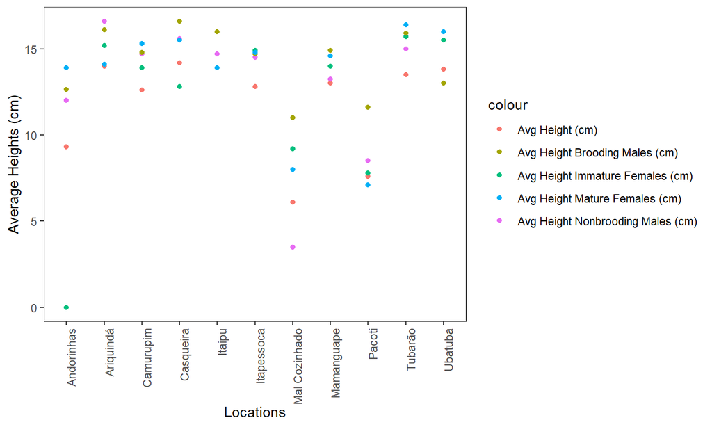

## **Size and Visible Populations**

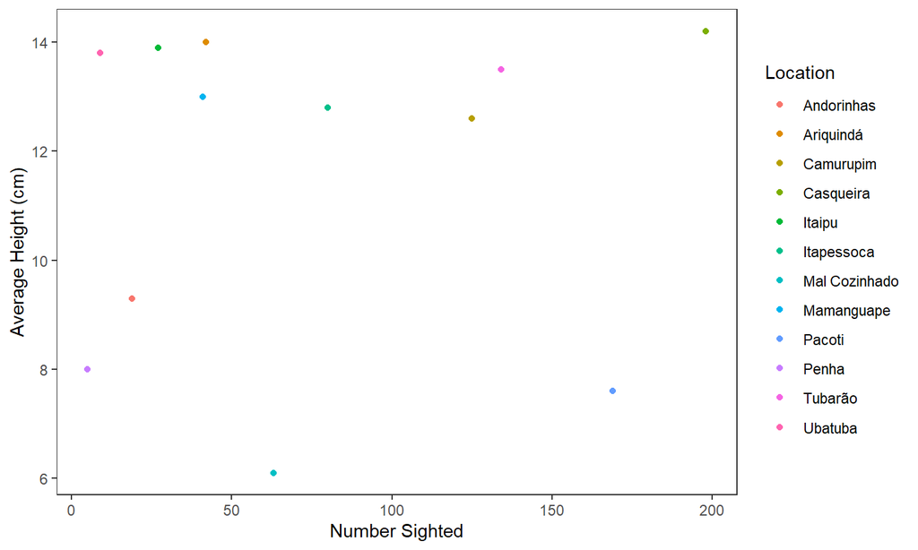

## **Mean, Min, and Max Height**

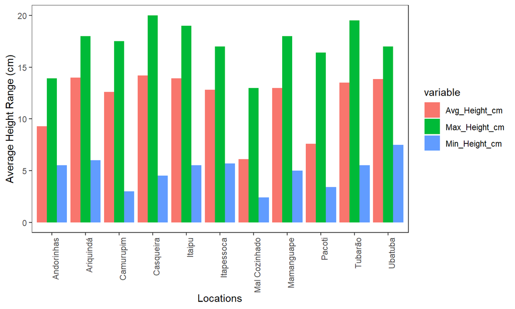

## **Conclusion**

Casqueira had both the highest visible population and the

largest average size. The largest overall popluations and

average sizes occured along the northern coast of Brazil.

Being a small coastline compared to the eastern side of

Brazil it would be a good idea to stay north if your goal

is to see *Hippocampus reidi* in the wild.